# Welfare in Experimental News Markets

Data Description and Analysis

Modified

October 31, 2023

The follow analysis is implemented in [R](https://www.r-project.org/about.html) [version 4.1.1 (2021-08-10) – “Kick Things”]

```r
library(tidyverse)
library(gridExtra)
library(readxl)
library(ggthemes)
library(knitr)
library(kableExtra)
library(xtable)
library(texreg)
library(broom)
library(lme4)
```

# 1 Dataset

- These are the choice data

Download CHOICES.csv.zip

- These are the questionnaire data

Download QUESTIONNAIRE.csv.zip

- These are the time on page data

Download TIMES.csv.zip

- Load the datasets

```r
# Main data source: choices
d <- read_csv("./CHOICES.csv") %>%
      mutate(Correct_C=ifelse(State==Choice_C,"Correct","Wrong")) %>%
      mutate(Payoff=ifelse(Type=="A",
      ifelse(Choice_C=="black",1200,400),
      ifelse(Type=="B",ifelse(Choice_C=="red",1200,400),
      ifelse(Correct_C=="Correct",600,200)))) %>%
      mutate(Cost=ifelse(Type=="A",abs(Drawn-Report_A)*25/3,ifelse(Type=="B",abs(Drawn-Report_B)*25/3,0))) %>%
      mutate(Net_payoff=(Payoff-Cost)) %>%
      mutate(Net_payoff=ifelse((Treatment=="Monopoly" & Type=="B"),Payoff,Net_payoff))

# Questionnaire data
d.q <- read_csv("./QUESTIONNAIRE.csv")

# Time on page data
d.t <- read_csv("./TIMES.csv") %>% arrange(session_code,participant_code,epoch_time) %>%
  rename(participant.code=participant_code) %>% arrange(participant.code, round_number)
```

## 1.1 Main variables

- *Treatment*: treatment identifier
  - Competition = COMP; Monopoly=MONO
- *session.code*: session unique identifier
- *participant.code*: participant’s unique identifier
- *Type*: role
  - A = $Sender_1$
  - B = $Sender_2$
  - C = $DM$
- *Group*: match identifier in session and round
- *Round*: Round identifier (1–30)
- *Drawn*: randomly drawn number ($drawn$)
  - $\{-100, ... 100\}$
- *Report_A*: number reported by $Sender_1$
  - $\{-100, ... 100\}$
- *Report_B*: number reported by $Sender_2$
  - $\{-100, ... 100\}$
- *Choice_C*: state chosen by
  - $\{Red, Black\}$
- *State* : actual state
  - $\{Red, Black\}$
- *Bel_A1*: the probability that Player A is going to report the value truthfully
  - 1: 0%-20%; 2:21%-40%; 3:41%-60%; 4:61%-80%; 5:81%-100%<
- *Bel_A2*: the probability that Player C is going to choose Black
  - 1: 0%-20%; 2:21%-40%; 3:41%-60%; 4:61%-80%; 5:81%-100%<
- *Payoff*: Earnings from the choice
- *Cost*: Cost of signal
- *Net_payoff*: Earnings from the choice - Cost of signal
- *Correct_C*: whether the $DM$ choiceis correct
  - $\{Correct, Wrong\}$

# 2 Sample descriptives

- Number of sessions:

  | n |
  | --- |
  | 7 |

  - Number of sessions by treatment:

    | Treatment | n |
    | --- | --- |
    | Competition | 3 |
    | Monopoly | 4 |

- Number of participants:

  | n |
  | --- |
  | 192 |

  - Number of participants by role

    | Type | n |
    | --- | --- |
    | A | 64 |
    | B | 64 |
    | C | 64 |

  - Number of participants by treatment

    | Treatment | n |
    | --- | --- |
    | Competition | 96 |
    | Monopoly | 96 |

  - Number of participants by treatment and role:

    | Treatment | Type | n |
    | --- | --- | --- |
    | Competition | A | 32 |
    | Competition | B | 32 |
    | Competition | C | 32 |
    | Monopoly | A | 32 |
    | Monopoly | B | 32 |
    | Monopoly | C | 32 |

# 3 Senders

## 3.1 Figure 1: Drawn and reported values by treatment.

### 3.1.1 MONO

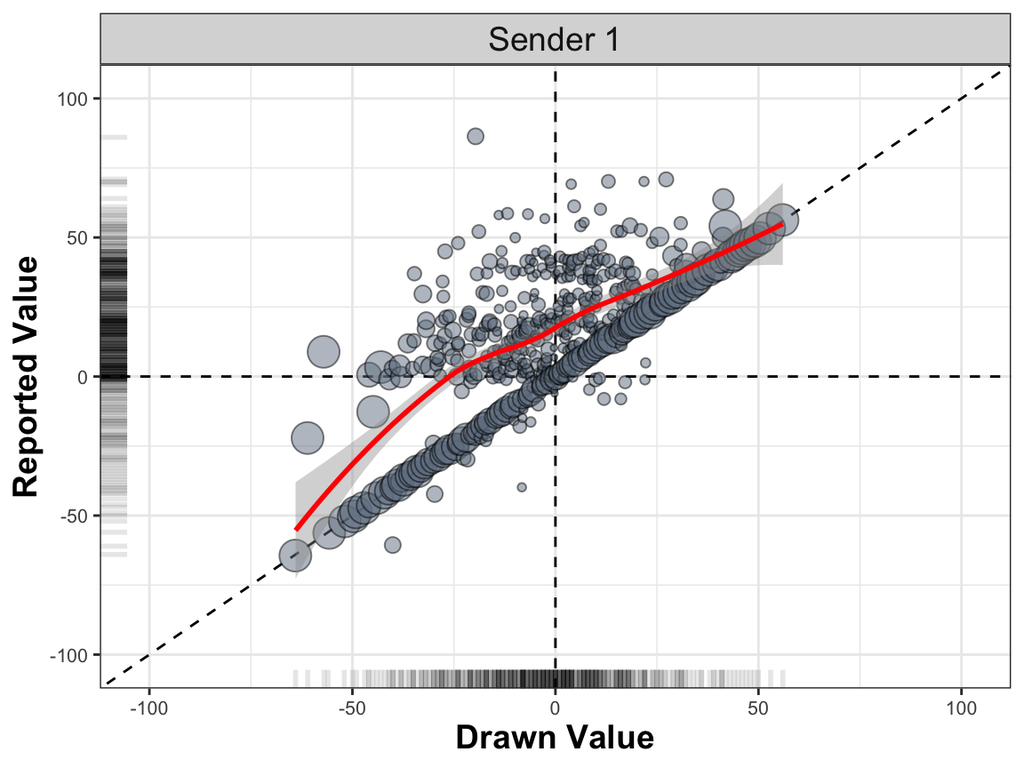

```r
marginal<- d %>%  filter(Treatment=="Monopoly") %>%
                  gather("Type","Value",8:8) %>%
                  group_by(Type, Drawn) %>%
                  count(Value) %>%
                  mutate(Type=ifelse(Type=="Report_A","Sender 1","Sender 2")) %>%
                  mutate(Freq=-99)

d %>% filter(Treatment=="Monopoly") %>%
      gather("Type","Value",8:8) %>%
      group_by(Type, Drawn) %>%
      count(Value) %>%
      mutate(Type=ifelse(Type=="Report_A","Sender 1","Sender 2")) %>%
      mutate(Freq=prop.table(n)) %>%
      ggplot(aes(x = Drawn, y = Value,  size=Freq))+#
      geom_abline(intercept=0,slope=1,linetype=2)+
      geom_hline(yintercept=0,linetype=2)+
      geom_vline(xintercept=0,linetype=2)+
      geom_jitter(pch=21,alpha=.5,color="black",fill="slategray")+
      geom_smooth(color="red")+
      geom_rug(data=marginal,col="black",alpha=0.1, size=1)+
      theme_bw()+
      scale_x_continuous(limits=c(-102,102))+
      scale_y_continuous(limits=c(-102,102))+
      scale_fill_gradient(low="slategray1",high="slategray")+
      scale_size(guide = "none")+
      facet_wrap(.~Type)+
      theme_bw()+ # the theme
      labs(
      y = "Reported Value",
      x= "Drawn Value",
      fill="Freq", color="Freq",size= "Subject")+ # labels
      theme(legend.position="none",
      axis.text=element_text(size=8),
      axis.title=element_text(size=14,face="bold"),
      strip.text.x = element_text(size = 14)) #axis
```

```r
ggsave("MONO_report.png",width=6, height=5,dpi=300)
```

### 3.1.2 COMP

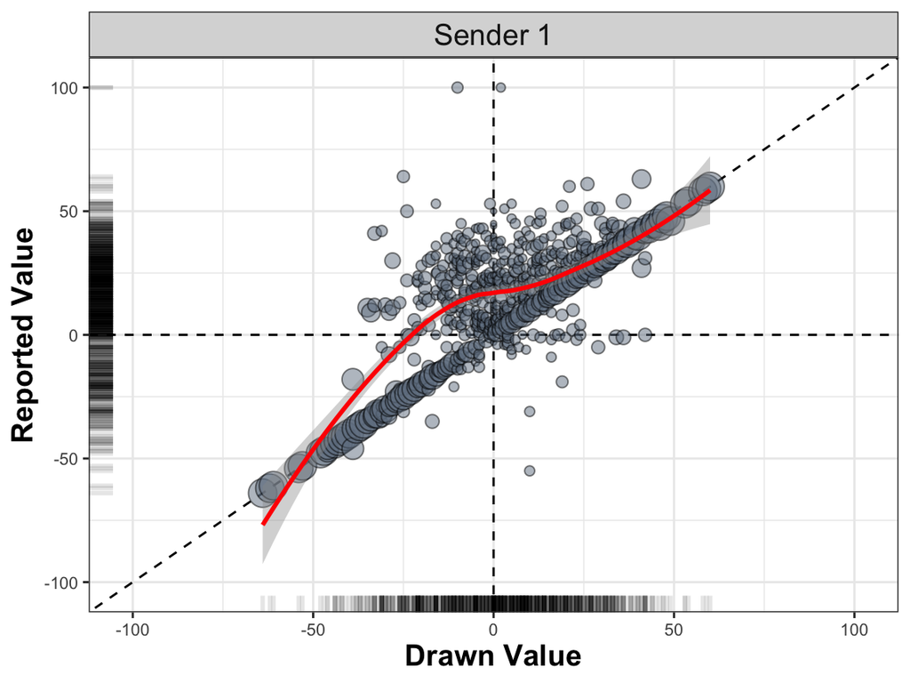

```r
marginal<- d %>%  filter(Treatment=="Competition" & (Type=="C")) %>%
                  select(Drawn,Report_A,Report_B) %>%
                  gather("Type","Value",2:3) %>%
                  group_by(Type) %>%
                  mutate(Freq=-99)%>%
                  mutate(Type=ifelse(Type=="Report_A","Sender 1","Sender 2"))

g <-
d %>% filter(Treatment=="Competition" & (Type=="C")) %>%
      gather("Type","Value",8:9) %>%
      group_by(Type, Drawn) %>%
      count(Value) %>%
      mutate(Freq=prop.table(n)) %>%
      mutate(Type=ifelse(Type=="Report_A","Sender 1","Sender 2")) %>%
      ggplot(aes(x = Drawn, y = Value, fill = Freq, size=Freq))+
      geom_abline(intercept=0,slope=1,linetype=2)+
      geom_hline(yintercept=0,linetype=2)+
      geom_vline(xintercept=0,linetype=2)+
      geom_point(pch=21,alpha=.5,color="black")+
      geom_smooth(color="red")+
      geom_rug(data=marginal,col="black",alpha=0.1, size=1)+
      theme_bw()+
      scale_x_continuous(limits=c(-102,102))+
      scale_y_continuous(limits=c(-102,102))+
      scale_fill_gradient(low="slategray1",high="slategray")+
      scale_size(guide = "none")+
      facet_wrap(.~Type, ncol=1)+
      theme_bw()+
      labs(
      y = "Reported Value",
      x= "Drawn Value",
      fill="Freq", color="Freq",size= "Subject")+
      theme(legend.position="none",
      axis.text=element_text(size=8),
      axis.title=element_text(size=14,face="bold"),
      strip.text.x = element_text(size = 14)
      ) #axis

# Only Type 1

d %>% filter(Treatment=="Competition" & (Type=="C")) %>%
      gather("Type","Value",8:9) %>%
      group_by(Type, Drawn) %>%
      count(Value) %>%
      mutate(Freq=prop.table(n)) %>%
      mutate(Type=ifelse(Type=="Report_A","Sender 1","Sender 2")) %>%
  filter(Type=="Sender 1") |>
    mutate(Type2="Sender 1") |>
      ggplot(aes(x = Drawn, y = Value,  size=Freq))+
      geom_abline(intercept=0,slope=1,linetype=2)+
      geom_hline(yintercept=0,linetype=2)+
      geom_vline(xintercept=0,linetype=2)+
      geom_point(pch=21,alpha=.5,color="black",fill="slategray")+
      geom_smooth(color="red")+
      geom_rug(data=marginal |> filter(Type=="Sender 1"),col="black",alpha=0.1, size=1)+
      theme_bw()+
      scale_x_continuous(limits=c(-102,102))+
      scale_y_continuous(limits=c(-102,102))+
      scale_fill_gradient(low="slategray1",high="slategray")+
      scale_size(guide = "none")+
      facet_wrap(.~Type2, ncol=1)+
      theme_bw()+
      labs(
      y = "Reported Value",
      x= "Drawn Value",
      fill="Freq", color="Freq",size= "Subject")+
      theme(legend.position="none",
      axis.text=element_text(size=8),
      axis.title=element_text(size=14,face="bold"),
      strip.text.x = element_text(size = 14)
      ) #axis
```

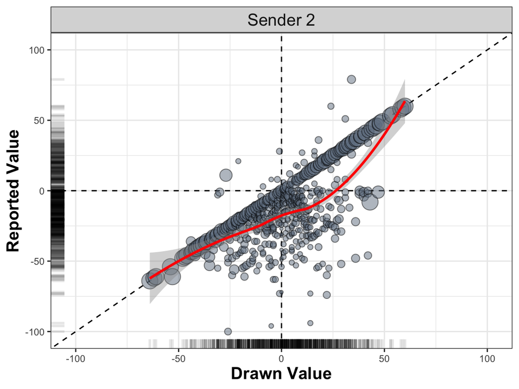

```r
ggsave("COMP_report_1.png",width=6, height=5,dpi=300)

## Only Type 2

d %>% filter(Treatment=="Competition" & (Type=="C")) %>%
      gather("Type","Value",8:9) %>%
      group_by(Type, Drawn) %>%
      count(Value) %>%
      mutate(Freq=prop.table(n)) %>%
      mutate(Type=ifelse(Type=="Report_A","Sender 1","Sender 2")) %>%
  filter(Type=="Sender 2") |>
  mutate(Type2="Sender 2") |>
      ggplot(aes(x = Drawn, y = Value, size=Freq))+
      geom_abline(intercept=0,slope=1,linetype=2)+
      geom_hline(yintercept=0,linetype=2)+
      geom_vline(xintercept=0,linetype=2)+
      geom_point(pch=21,alpha=.5,color="black",fill="slategray")+
      geom_smooth(color="red")+
      geom_rug(data=marginal |> filter(Type=="Sender 2"),col="black",alpha=0.1, size=1)+
      theme_bw()+
      scale_x_continuous(limits=c(-102,102))+
      scale_y_continuous(limits=c(-102,102))+
      scale_fill_gradient(low="slategray1",high="slategray")+
      scale_size(guide = "none")+
      facet_wrap(.~Type2, ncol=1)+
      theme_bw()+
      labs(
      y = "Reported Value",
      x= "Drawn Value",
      fill="Freq", color="Freq",size= "Subject")+
      theme(legend.position="none",
      axis.text=element_text(size=8),
      axis.title=element_text(size=14,face="bold"),
      strip.text.x = element_text(size = 14)
      ) #axis
```

```r
ggsave("COMP_report_2.png",width=6, height=5,dpi=300)
```

## 3.2 Descriptives

- Truth telling

```r
d %>% select(participant.code,Treatment,Type,Drawn, Report_A, Report_B) %>%
  mutate(truth_telling=ifelse(Type=="A",ifelse(Drawn == Report_A,1,0), ifelse(Type=="B",ifelse(Drawn == Report_B,1,0),NA))) %>%
  select(participant.code, Treatment, Type, truth_telling) %>%
    filter(Type=="A" | Type=="B") %>%
  group_by(Treatment) %>%
  count(truth_telling) %>%
  na.omit() %>%
  mutate(Freq=prop.table(n)) %>%
  kable() %>% kable_minimal()
```

| Treatment | truth_telling | n | Freq |
| --- | --- | --- | --- |
| Competition | 0 | 975 | 0.5078125 |
| Competition | 1 | 945 | 0.4921875 |
| Monopoly | 0 | 418 | 0.4354167 |
| Monopoly | 1 | 542 | 0.5645833 |

- Deviation from true value

```r
d %>% select(participant.code,Treatment,Type,Drawn, Report_A, Report_B) %>%
      gather("Key","Value",5:6) %>%
      mutate(Dist=ifelse(Key=="Report_A",(Value-Drawn),Drawn-Value)) %>%
      filter((Type=="A" & Key=="Report_A") | (Type=="B" & Key=="Report_B"))  %>%
      group_by(participant.code,Treatment) %>%
      summarise_at("Dist",mean) %>%
      group_by(Treatment) %>%
      summarize_at("Dist",list(N=~n(),Mean=~mean(.,na.rm=TRUE), SD=~sd(.,na.rm=TRUE), Median=~median(.,na.rm=TRUE))) %>%
      kable() %>% kable_minimal()
```

| Treatment | N | Mean | SD | Median |
| --- | --- | --- | --- | --- |
| Competition | 64 | 9.614062 | 9.904676 | 7.216667 |
| Monopoly | 64 | 9.634375 | 10.975948 | 6.700000 |

- Deviation from true value when drawn is adverse

```r
d %>% select(participant.code,Treatment,Type,Drawn, Report_A, Report_B) %>%
      gather("Key","Value",5:6) %>%
      mutate(Dist=ifelse(Key=="Report_A",(Value-Drawn),Drawn-Value)) %>%
      filter((Type=="A" & Key=="Report_A") | (Type=="B" & Key=="Report_B"))  %>%
      filter((Type=="A" & Drawn<0) | (Type=="B" & Drawn>0)) %>%
      group_by(participant.code,Treatment) %>%
      summarise_at("Dist",mean) %>%
      group_by(Treatment) %>%
      summarize_at("Dist",list(N=~n(),Mean=~mean(.,na.rm=TRUE), SD=~sd(.,na.rm=TRUE), Median=~median(.,na.rm=TRUE))) %>%
  kable() %>% kable_minimal()
```

| Treatment | N | Mean | SD | Median |
| --- | --- | --- | --- | --- |
| Competition | 64 | 13.38616 | 11.78028 | 10.33333 |
| Monopoly | 64 | 13.29056 | 14.04189 | 10.68125 |

## 3.3 Table 2: Signal Costs (individual observations).

- Monopoly (average at individual level)

```r
d %>% filter(Treatment=="Monopoly" & Type=="A") %>%
      group_by(Type) %>%
      summarize_at("Cost",list(N=~n(),Mean=~mean(.), SD=~sd(.), Median=~median(.))) %>%
      kable() %>% kable_minimal()
```

| Type | N | Mean | SD | Median |
| --- | --- | --- | --- | --- |
| A | 960 | 85.85938 | 134.6635 | 0 |

- Competition (average at individual level)

```r
d %>% filter(Treatment=="Competition" & (Type=="A"| Type=="B")) %>%
      group_by(Type) %>%
      summarize_at("Cost",list(N=~n(),Mean=~mean(.), SD=~sd(.), Median=~median(.))) %>%
      kable() %>% kable_minimal()
```

| Type | N | Mean | SD | Median |
| --- | --- | --- | --- | --- |
| A | 960 | 88.53299 | 127.3724 | 16.66667 |
| B | 960 | 93.09028 | 145.9500 | 0.00000 |

- Tests
  - Take average at the individual level

```r
d |> group_by(participant.code, Type, Treatment) %>%
  summarize_at("Cost",mean) -> dt

wilcox.test(
dt |> filter(Treatment=="Competition" & Type=="A") |> pull(Cost),
dt |> filter(Treatment=="Monopoly" & Type=="A") |> pull(Cost),
) |> tidy() |> kable() %>% kable_minimal()
```

| statistic | p.value | method | alternative |
| --- | --- | --- | --- |
| 577 | 0.3863423 | Wilcoxon rank sum test with continuity correction | two.sided |

```r
wilcox.test(
dt |> filter(Treatment=="Competition" & Type=="B") |> pull(Cost),
dt |> filter(Treatment=="Competition" & Type=="A") |> pull(Cost),
) |> tidy() |> kable() %>% kable_minimal()
```

| statistic | p.value | method | alternative |
| --- | --- | --- | --- |
| 482.5 | 0.6969665 | Wilcoxon rank sum test with continuity correction | two.sided |

```r
wilcox.test(
dt |> filter(Treatment=="Competition" & Type=="B") |> pull(Cost),
dt |> filter(Treatment=="Monopoly" & Type=="A") |> pull(Cost),
) |> tidy() |> kable() %>% kable_minimal()
```

| statistic | p.value | method | alternative |
| --- | --- | --- | --- |
| 557 | 0.5499899 | Wilcoxon rank sum test with continuity correction | two.sided |

```r
#pull A and B together

wilcox.test(
dt |> filter(Treatment=="Competition" & Type!="C") |> pull(Cost),
dt |> filter(Treatment=="Monopoly" & Type=="A") |> pull(Cost),
) |> tidy() |> kable() %>% kable_minimal()
```

| statistic | p.value | method | alternative |
| --- | --- | --- | --- |
| 1134 | 0.3946434 | Wilcoxon rank sum test with continuity correction | two.sided |

```r
#pull A and B together at session elevel

d |> group_by(session.code, Type, Treatment) %>%
  summarize_at("Cost",mean) -> dt

wilcox.test(
dt |> filter(Treatment=="Competition" & Type!="C") |> pull(Cost),
dt |> filter(Treatment=="Monopoly" & Type=="A") |> pull(Cost),
) |> tidy() |> kable() %>% kable_minimal()
```

| statistic | p.value | method | alternative |
| --- | --- | --- | --- |
| 13 | 0.9142857 | Wilcoxon rank sum exact test | two.sided |

# 4 Decision Maker

## 4.1 Figure 2: Decision-makers accuracy by treatment.

### 4.1.1 COMP

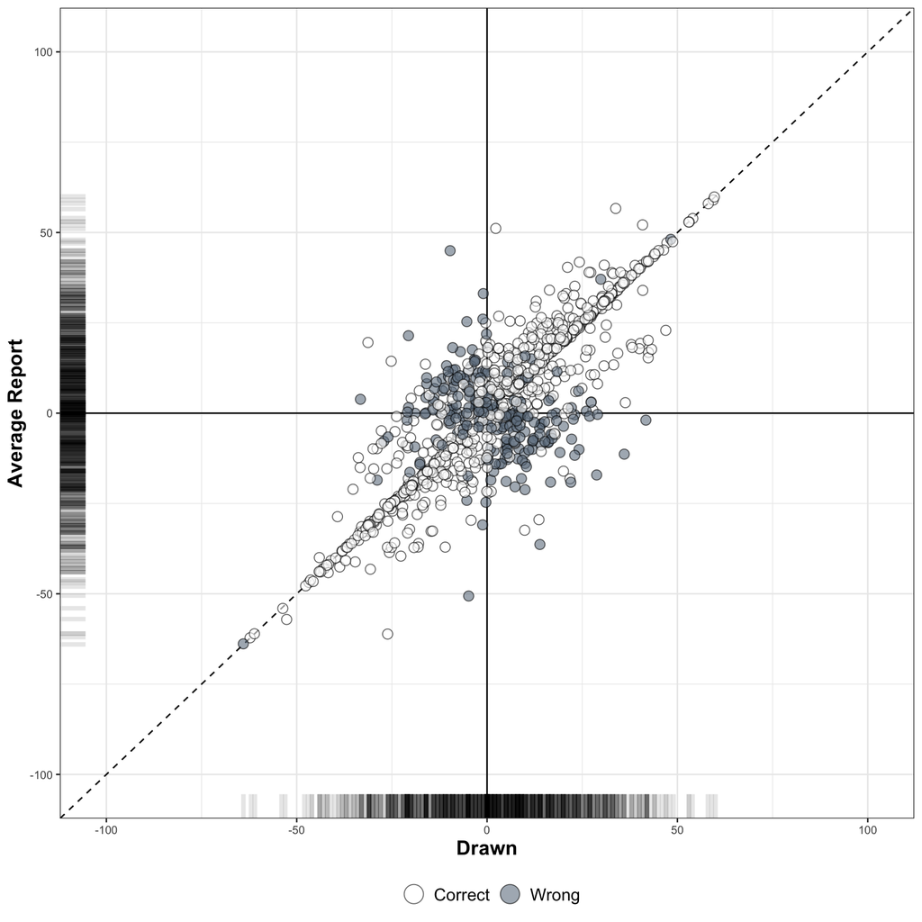

```r
d %>% filter(Treatment=="Competition" & Type=="C") %>%
      select(Treatment, session.code, Group, Round, Drawn, Report_A, Report_B, Choice_C, Correct_C) %>%
      distinct() |> mutate(AVG_report=(Report_A+Report_B)/2)  -> dt.g


marginal<- dt.g %>%
    select(Drawn,AVG_report) %>%
  mutate(Correct_C=NA) %>% arrange(AVG_report)

      ggplot(dt.g  ,aes(y = AVG_report, x=Drawn, fill = as_factor(Correct_C)))+
      geom_hline(yintercept=0)+
      geom_vline(xintercept=0)+
      geom_abline(intercept=0,slope=1,linetype=2)+
      geom_jitter(alpha=.6,pch=21,size=3)+
      # geom_smooth()+
      geom_rug(data=marginal,col="black",alpha=0.1, size=1.5)+
      scale_x_continuous(limits=c(-102,102))+
      scale_y_continuous(limits=c(-102,102))+
      #scale_fill_brewer(palette="Paired")+
         scale_fill_manual(values=c("white","slategray"))+
      scale_size(guide = "none")+
      theme_bw()+ # the theme
      labs(
      # title="Guesses and reported values",
      #    subtitle="Monopoly",
      x = "Drawn",
      y= "Average Report",
      fill="", color="Subject",size= "Subject")+ # labels
      theme(legend.position="bottom",
      axis.text=element_text(size=8),
      axis.title=element_text(size=14,face="bold"),
      legend.text=element_text(size=12)) +
      guides(fill = guide_legend(override.aes = list(size=6))) #axis
```

```r
      ggsave("COMP_guesses_AVERAGE.png",width=6, height=6,dpi=300)
```

### 4.1.2 MONO

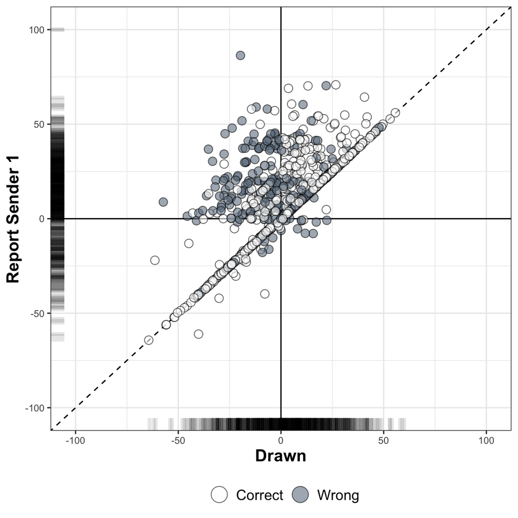

```r
marginal<- d %>%  filter(Treatment=="Competition" & (Type=="C")) %>%
                  select(Drawn,Report_A) %>%
                  mutate(Correct_C=NA)

# DM is better of if RED and DRAWN <=0 AND IF BLACK and DRAWN>=0


d %>% filter(Treatment=="Monopoly" & (Type=="C")) %>%
      select(Treatment, session.code, Group, Round, Drawn, Report_A, Correct_C) %>%
      distinct()  -> dt.g

      ggplot(dt.g,aes(y = Report_A, x=Drawn, fill = as_factor(Correct_C)))+
      geom_hline(yintercept=0)+
      geom_vline(xintercept=0)+
      geom_abline(intercept=0,slope=1,linetype=2)+
      geom_jitter(alpha=.6,pch=21,size=3)+
      # geom_smooth()+
      geom_rug(data=marginal,col="black",alpha=0.1, size=1.5)+
      scale_x_continuous(limits=c(-102,102))+
      scale_y_continuous(limits=c(-102,102))+
      #scale_fill_brewer(palette="Paired")+
         scale_fill_manual(values=c("white","slategray"))+
      scale_size(guide = "none")+
      theme_bw()+ # the theme
      labs(
      # title="Guesses and reported values",
      #    subtitle="Monopoly",
      x = "Drawn",
      y= "Report Sender 1",
      fill="", color="Subject",size= "Subject")+ # labels
      theme(legend.position="bottom",
      axis.text=element_text(size=8),
      axis.title=element_text(size=14,face="bold"),
      legend.text=element_text(size=12)) +
      guides(fill = guide_legend(override.aes = list(size=6))) #axis
```

```r
      ggsave("MONO_guesses.png",width=6, height=6,dpi=300)

# NEW (but not effective)

  #  dt.g |>
  #    count(Correct_C, Report_A, Drawn) %>%
  #     group_by(Drawn, Report_A) |>
  #     mutate(Freq=prop.table(n)) %>%
  #     ggplot(aes(y = Report_A, x=Drawn, fill = as_factor(Correct_C), size=Freq))+
  #     geom_hline(yintercept=0)+
  #     geom_vline(xintercept=0)+
  #     geom_abline(intercept=0,slope=1,linetype=2)+
  #     geom_point(alpha=.6,pch=21)+
  #     geom_rug(data=marginal,col="black",alpha=0.1, size=1.5)+
  #     scale_x_continuous(limits=c(-102,102))+
  #     scale_y_continuous(limits=c(-102,102))+
  #     scale_fill_brewer(palette="Okabe-Ito")+
  #        scale_fill_manual(values=c("white","slategray"))+
  #     scale_size(guide = "none")+
  #     theme_bw()+ # the theme
  #     labs(
  #     # title="Guesses and reported values",
  #     #    subtitle="Monopoly",
  #     x = "Drawn",
  #     y= "Report Sender 1",
  #     fill="", color="Subject",size= "Subject")+ # labels
  #     theme(legend.position="bottom",
  #     axis.text=element_text(size=8),
  #     axis.title=element_text(size=14,face="bold"),
  #     legend.text=element_text(size=12)) +
  #     guides(fill = guide_legend(override.aes = list(size=6))) #axis
```

### 4.1.3 Descriptives

```r
d  %>%  group_by(Correct_C, Treatment) %>%
        count(Correct_C) %>%
        ungroup() %>%
        group_by( Treatment) %>%
        mutate(Freq=prop.table(n)) %>%
        kable() %>% kable_minimal()
```

| Correct_C | Treatment | n | Freq |
| --- | --- | --- | --- |
| Correct | Competition | 2130 | 0.7395833 |
| Correct | Monopoly | 2079 | 0.7218750 |
| Wrong | Competition | 750 | 0.2604167 |
| Wrong | Monopoly | 801 | 0.2781250 |

- Monopoly

```r
d %>% filter(Treatment=="Monopoly" & Type=="C") %>%
      select(Treatment, session.code, Group, Round, Drawn, Report_A,Drawn, Choice_C, Correct_C) %>%
      mutate(Deceitful=ifelse(Report_A>0 & Drawn<0,"Deceit",ifelse(Report_A>0 & Drawn>0,"Honest",NA))) %>% distinct() %>%
      group_by(Deceitful) %>%
      count(Correct_C) %>%
      mutate(Freq=prop.table(n)) %>%
      kable() %>% kable_minimal()
```

| Deceitful | Correct_C | n | Freq |
| --- | --- | --- | --- |
| Deceit | Correct | 55 | 0.2925532 |
| Deceit | Wrong | 133 | 0.7074468 |
| Honest | Correct | 372 | 0.8322148 |
| Honest | Wrong | 75 | 0.1677852 |
| NA | Correct | 266 | 0.8184615 |
| NA | Wrong | 59 | 0.1815385 |

- Competition

```r
d %>% filter(Treatment=="Competition" & (Type=="C")) %>%
      select(Treatment, session.code, Group, Round, Drawn, Report_A, Report_B, Choice_C, Correct_C) %>% mutate(Consistency=ifelse(Report_A*Report_B>0,"Same sign","Opposite signs")) %>% distinct() %>% mutate(Avg_report=(Report_A+Report_B)/2, dist=abs(Report_A-Report_B)) %>%
      group_by(Consistency) %>%
      count(Correct_C) %>%
      mutate(Freq=prop.table(n)) %>%
      kable(caption = "Report S1 vs Report S2") %>% kable_minimal()
```

Report S1 vs Report S2

| Consistency | Correct_C | n | Freq |
| --- | --- | --- | --- |
| Opposite signs | Correct | 216 | 0.4886878 |
| Opposite signs | Wrong | 226 | 0.5113122 |
| Same sign | Correct | 494 | 0.9536680 |
| Same sign | Wrong | 24 | 0.0463320 |

- Compare average report with drawn value

```r
d %>% filter(Treatment=="Competition" & (Type=="C")) %>%
      select(Treatment, session.code, Group, Round, Drawn, Report_A, Report_B, Choice_C, Correct_C) %>% mutate(Avg_report = (Report_A + Report_B) / 2, dist = abs(Report_A - Report_B)) |>
      mutate(Consistency=ifelse(Avg_report*Drawn>0,"Same sign","Opposite signs")) %>% distinct() %>% mutate(Avg_report=(Report_A+Report_B)/2, dist=abs(Report_A-Report_B)) %>%
      group_by(Consistency) %>%
      count(Correct_C) %>%
      mutate(Freq=prop.table(n)) %>%
      kable(caption="Average report vs drawn value") %>% kable_minimal()
```

Average report vs drawn value

| Consistency | Correct_C | n | Freq |
| --- | --- | --- | --- |
| Opposite signs | Correct | 87 | 0.3140794 |
| Opposite signs | Wrong | 190 | 0.6859206 |
| Same sign | Correct | 623 | 0.9121523 |
| Same sign | Wrong | 60 | 0.0878477 |

# 5 Welfare

## 5.1 Table 3: Net Payoffs (individual observations).

```r
d %>%
      group_by(Treatment,Type) %>%
      summarise_at("Net_payoff",list(N=~n(),Mean=~mean(.,na.rm=TRUE), Median=~median(.,na.rm=TRUE), SD=~sd(.,na.rm=TRUE)))%>% na.omit() %>%
      kable() %>% kable_minimal()
```

| Treatment | Type | N | Mean | Median | SD |
| --- | --- | --- | --- | --- | --- |
| Competition | A | 960 | 738.9670 | 862.5 | 404.1758 |
| Competition | B | 960 | 679.4097 | 400.0 | 397.5772 |
| Competition | C | 960 | 495.8333 | 600.0 | 175.6363 |
| Monopoly | A | 960 | 778.3073 | 900.0 | 386.6147 |
| Monopoly | B | 960 | 735.8333 | 400.0 | 395.0256 |
| Monopoly | C | 960 | 488.7500 | 600.0 | 179.3235 |

```r
d %>% mutate(unique_group=paste(Group,Round,session.code,sep="_")) %>% group_by(Treatment,unique_group) %>% distinct() %>%
      summarise_at("Net_payoff",sum) %>%
      group_by(Treatment) %>%
      summarise_at("Net_payoff",list(N=~n(),Mean=~mean(.,na.rm=TRUE), Median=~median(.,na.rm=TRUE), SD=~sd(.,na.rm=TRUE)))%>% na.omit() %>%
      kable() %>% kable_minimal()
```

| Treatment | N | Mean | Median | SD |
| --- | --- | --- | --- | --- |
| Competition | 960 | 1914.210 | 2033.333 | 310.0672 |
| Monopoly | 960 | 2002.891 | 2191.667 | 263.2047 |

## 5.2 Table 4: Net Payoffs

```r
d.reg <-
  full_join(
    d,
    d.q %>% select(-Treatment),
    by="participant.code"
            ) %>% mutate(trust_scale=ifelse(trust=="No, bisogna sempre essere prudenti",0,ifelse(trust=="No, spesso bisogna essere prudenti",1,ifelse(trust=="Sì, ti puoi fidare quasi sempre",3,4)))) %>%
mutate(honesty_scale=ifelse(honesty=="No, le persone si comportano quasi sempre in modo corretto",2,ifelse(honesty=="Sì, cercano di approfittarsene quasi sempre",1,0))) %>%
mutate(gender=as_factor(gender)) %>% mutate(gender=factor(gender,levels=c("Femmina","Maschio","Non binario"))) %>%
mutate(Treatment=as_factor(Treatment))

d.reg$Treatment <- factor(d.reg$Treatment, levels=c("Monopoly", "Competition"))
```

```r
#--------------------------------------------------
fit.A <-  lmer(Net_payoff ~ Round + as_factor(Treatment)*Drawn+
               (gender) + age + risk_taker  + (trust_scale ) + (honesty_scale)
                + (1|session.code:participant.code),
             data=d.reg %>% filter(Type=="A"), control=lmerControl(optimizer= "bobyqa"))

fit.B <-  lmer(Net_payoff ~ Round + as_factor(Treatment)*Drawn+
               (gender) + age + risk_taker  + (trust_scale ) +(honesty_scale)
                + (1|session.code:participant.code),
             data=d.reg %>% filter(Type=="B" & gender!="Non binario"), control=lmerControl(optimizer= "bobyqa"))

fit.C <-  lmer(Net_payoff ~ Round + as_factor(Treatment) *abs(Drawn)+
               (gender) + age + risk_taker  + (trust_scale ) +(honesty_scale)
                +(1|session.code:participant.code) ,
             data=d.reg %>% filter(Type=="C"), control=lmerControl(optimizer= "bobyqa"))

fit.all <- lmer(Net_payoff ~ Round  + as_factor(Treatment)*abs(Drawn)+
               (gender) + age + risk_taker + (trust_scale ) +(honesty_scale)
              +(1|session.code:participant.code) ,
             data=d.reg %>% filter(gender!="Non binario"), control=lmerControl(optimizer= "bobyqa"))
#--------------------------------------------------

htmlreg(list(fit.A,fit.B,fit.C,fit.all),
                 custom.model.names = c("A","B","C","all"),
                     single.row = TRUE,
                     bold = 0.05,
                     booktabs = TRUE,
                     dcolumn = TRUE,
                     digits=3,
                     stars = c(0.001, 0.01, 0.05, 0.1))
```

Statistical models

|  | A | B | C | all |
| --- | --- | --- | --- | --- |
| (Intercept) | **747.561** (103.270)*** | **554.838** (74.679)*** | **432.068** (50.382)*** | **661.643** (87.167)*** |
| Round | -0.017 (0.849) | -0.375 (0.887) | **1.384** (0.444)** | 0.481 (0.515) |
| as_factor(Treatment)Competition | **-58.166** (22.831)* | **-42.114** (18.838)* | -25.561 (16.365) | **-59.807** (24.510)* |
| Drawn | **10.456** (0.518)*** | **-8.765** (0.544)*** |  |  |
| genderMaschio | -2.442 (22.002) | -2.335 (16.808) | -12.974 (12.597) | -7.964 (20.593) |
| age | 1.375 (4.534) | **6.762** (3.230)* | 0.569 (1.845) | 0.016 (3.580) |
| risk_taker | -4.285 (5.509) | 8.078 (4.696)<sup>·</sup> | 0.005 (3.148) | 0.663 (5.270) |
| trust_scale | -8.975 (12.549) | 4.423 (10.901) | -4.570 (5.906) | -10.068 (11.359) |
| honesty_scale | 28.465 (18.762) | -10.934 (16.220) | -6.104 (11.790) | -6.314 (17.994) |
| as_factor(Treatment)Competition:Drawn | 1.432 (0.734)<sup>·</sup> | **-3.200** (0.760)*** |  |  |
| abs(Drawn) |  |  | **2.589** (0.452)*** | **1.118** (0.525)* |
| as_factor(Treatment)Competition:abs(Drawn) |  |  | **2.090** (0.636)** | **1.790** (0.739)* |
| AIC | 27169.835 | 27299.463 | 25149.084 | 82745.975 |
| BIC | 27236.367 | 27365.995 | 25215.805 | 82825.754 |
| Log Likelihood | -13572.918 | -13637.732 | -12562.542 | -41360.988 |
| Num. obs. | 1890 | 1890 | 1920 | 5700 |
| Num. groups: session.code:participant.code | 63 | 63 | 64 | 190 |
| Var: session.code:participant.code (Intercept) | 3554.789 | 316.658 | 1327.957 | 15593.552 |
| Var: Residual | 101993.382 | 111379.052 | 28117.934 | 112436.068 |

***p < 0.001; **p < 0.01; *p < 0.05; <sup>·</sup>p < 0.1

- using sum at the group level (robustness check)

```r
fit.all <- lmer(Net_payoff ~ Round  + as_factor(Treatment)*abs(Drawn)
              +(1|session.code) ,
             data=d.reg %>% mutate(Group_ID=paste(session.code,Group,Round,sep="_")) %>% group_by(session.code,Group_ID,Drawn,Round,Treatment) %>% summarise_at("Net_payoff",sum), control=lmerControl(optimizer= "bobyqa"))

htmlreg(list(fit.all),
                 custom.model.names = c("all"),
                     single.row = TRUE,
                     bold = 0.05,
                     booktabs = TRUE,
                     dcolumn = TRUE,
                     digits=3,
                     stars = c(0.001, 0.01, 0.05, 0.1))
```

Statistical models

|  | all |
| --- | --- |
| (Intercept) | **1949.883** (36.388)*** |
| Round | 1.013 (0.719) |
| as_factor(Treatment)Competition | **-194.002** (52.085)*** |
| abs(Drawn) | **3.395** (0.727)*** |
| as_factor(Treatment)Competition:abs(Drawn) | **5.316** (1.020)*** |
| AIC | 26980.908 |
| BIC | 27019.829 |
| Log Likelihood | -13483.454 |
| Num. obs. | 1920 |
| Num. groups: session.code | 7 |
| Var: session.code (Intercept) | 3909.646 |
| Var: Residual | 73958.664 |

***p < 0.001; **p < 0.01; *p < 0.05; <sup>·</sup>p < 0.1

- Are payoffs of DM higher in the last 15 rounds?

```r
#--------------------------------------------------

fit.C.rob <-  lmer(Net_payoff ~ ifelse(Round>15,1,0) + as_factor(Treatment) *abs(Drawn)+
               (gender) + age + risk_taker  + (trust_scale ) +(honesty_scale)
                +(1|session.code:participant.code) ,
             data=d.reg %>% filter(Type=="C"), control=lmerControl(optimizer= "bobyqa"))

#--------------------------------------------------

htmlreg(list(fit.C.rob),
                 custom.model.names = c("C rob"),
                     single.row = TRUE,
                     bold = 0.05,
                     booktabs = TRUE,
                     dcolumn = TRUE,
                     digits=3,
                     stars = c(0.001, 0.01, 0.05, 0.1))
```

Statistical models

|  | C rob |
| --- | --- |
| (Intercept) | **443.813** (50.055)*** |
| ifelse(Round > 15, 1, 0) | **19.922** (7.674)** |
| as_factor(Treatment)Competition | -25.387 (16.371) |
| abs(Drawn) | **2.562** (0.452)*** |
| genderMaschio | -12.955 (12.598) |
| age | 0.577 (1.845) |
| risk_taker | 0.010 (3.149) |
| trust_scale | -4.570 (5.907) |
| honesty_scale | -6.139 (11.791) |
| as_factor(Treatment)Competition:abs(Drawn) | **2.079** (0.636)** |
| AIC | 25146.368 |
| BIC | 25213.089 |
| Log Likelihood | -12561.184 |
| Num. obs. | 1920 |
| Num. groups: session.code:participant.code | 64 |
| Var: session.code:participant.code (Intercept) | 1326.815 |
| Var: Residual | 28163.109 |

***p < 0.001; **p < 0.01; *p < 0.05; <sup>·</sup>p < 0.1

# 6 Additional Results

## 6.1 Benchmarks

```r
# Typ: A, B (S1,S2) or C (DM)
# Treatm: Competition or Monopoly
#ref: the benchamrk
deviation <- function(Typ, Treatm,ref) {
x <- d |>
    filter((Type %in% Typ) & Treatment == Treatm) |>
    select(participant.code, Net_payoff) %>%
    group_by(participant.code) |>
    summarise_at("Net_payoff", ~ mean(.)) %>%
    pull(Net_payoff)

dev=x-ref

dev_perc <- dev / ref

return(
  paste(round(mean(dev_perc * 100), 3), " (", round(wilcox.test(dev_perc)$p.value, 3),")",sep="")
)
}
```

| Benchmark | DM | S1 | S2 | TOT |
| --- | --- | --- | --- | --- |
| Complete Info | 600 | 800 | 800 | 2200 |
| No Communication | 400 | 800 | 800 | 2000 |
| Cheap Talk | 400 | 800 | 800 | 2000 |

Deviatons from benchmark in % terms

### 6.1.1 Competition

| Benchmark | DM | S1 | S2 | TOT |
| --- | --- | --- | --- | --- |
| Complete Info | -17.361 (0) | -7.629 (0.002) | -15.074 (0) | 2200 |
| No Communication | 23.958 (0) | -7.629 (0.002) | -15.074 (0) | 2000 |
| Cheap Talk | 23.958 (0) | -7.629 (0.002) | -15.074 (0) | 2000 |

### 6.1.2 Monopoly

| Benchmark | DM | S1 | S2 | TOT |
| --- | --- | --- | --- | --- |
| Complete Info | -18.542 (0) | -2.712 (0.214) | -8.021 (0) | 2200 |
| No Communication | 22.188 (0) | -2.712 (0.214) | -8.021 (0) | 2000 |
| Cheap Talk | 22.188 (0) | -2.712 (0.214) | -8.021 (0) | 2000 |

### 6.1.3 Equilibrium

[output not shown]

[output not shown]

## 6.2 Decision Times

```r
# join choices and times
IDa <- d %>% filter(Type=="A") %>% distinct(participant.code) %>% pull()
IDb <- d %>% filter(Type=="B") %>% distinct(participant.code) %>% pull()
IDc <- d %>% filter(Type=="C") %>% distinct(participant.code) %>% pull()

# codification error for session.code = 7lq6t6as, participant.code = yerm0n2w -> remove time on page =0
d.j <-
full_join(
d,
bind_rows(
d.t %>% filter(participant.code %in% IDa) %>% filter(page_name=="Slider_A") %>% filter(time_on_page!=0)%>% select(session_code, participant.code,time_on_page, round_number) %>% rename(Round=round_number,session.code=session_code),
d.t %>% filter(participant.code %in% IDb) %>% filter(page_name=="Slider_B") %>% filter(time_on_page!=0)%>% select(session_code, participant.code,time_on_page, round_number) %>% rename(Round=round_number,session.code=session_code),
d.t %>% filter(participant.code %in% IDc) %>% filter(page_name=="Slider_C") %>% filter(time_on_page!=0)%>% select(session_code, participant.code,time_on_page, round_number) %>% rename(Round=round_number,session.code=session_code)
),
by=c("session.code","participant.code","Round")
)
```

### 6.2.1 Sender

- Times in Competition and Monopoly

```r
d.j %>% filter(((Type == "A" | Type =="B") & Treatment=="Competition") | (Type == "A" & Treatment=="Monopoly")) %>% group_by(Treatment, participant.code) %>%
   summarise_at("time_on_page",mean) %>%
  summarise_at("time_on_page",list(N=~n(),Mean=~mean(.,na.rm=TRUE), SD=~sd(.,na.rm=TRUE), Median=~median(.,na.rm=TRUE))) %>%
  kable() %>% kable_minimal()
```

| Treatment | N | Mean | SD | Median |
| --- | --- | --- | --- | --- |
| Competition | 64 | 20.34948 | 9.681219 | 19.05000 |
| Monopoly | 32 | 20.53125 | 6.456521 | 19.61667 |

- Test at the individual level

```r
d.j %>% filter(((Type == "A" | Type =="B") & Treatment=="Competition") | (Type == "A" & Treatment=="Monopoly")) %>% group_by(Treatment, participant.code) %>%
  summarise_at("time_on_page",mean) %>%
  with(wilcox.test(time_on_page~Treatment)) %>% tidy() %>%
  kable() %>% kable_minimal()
```

| statistic | p.value | method | alternative |
| --- | --- | --- | --- |
| 950.5 | 0.5704491 | Wilcoxon rank sum test with continuity correction | two.sided |

- Time to lie and tell the truth

```r
d.j  %>% filter(((Type == "A" | Type =="B") & Treatment=="Competition") | (Type == "A" & Treatment=="Monopoly")) %>%
  mutate(truth=ifelse((Type == "A" & Report_A == Drawn) | (Type == "B" & Report_B == Drawn), 1, 0)) %>%
  group_by(truth, participant.code) %>%
  summarise_at("time_on_page",mean) %>%
  summarise_at("time_on_page",list(N=~n(),Mean=~mean(.,na.rm=TRUE), SD=~sd(.,na.rm=TRUE), Median=~median(.,na.rm=TRUE))) %>%
  kable()  %>% kable_minimal()
```

| truth | N | Mean | SD | Median |
| --- | --- | --- | --- | --- |
| 0 | 89 | 26.20470 | 15.062432 | 22.58333 |
| 1 | 93 | 17.91894 | 6.732458 | 16.26087 |

- Test at the individual level (average time when cheating and when not)

```r
test <-
d.j %>% filter(((Type == "A" | Type =="B") & Treatment=="Competition") | (Type == "A" & Treatment=="Monopoly")) %>%
   mutate(truth=ifelse((Type == "A" & Report_A == Drawn) | (Type == "B" & Report_B == Drawn), 1, 0)) %>%
  group_by(truth, participant.code) %>%
  summarise_at("time_on_page",mean)

wilcox.test(
full_join(test %>% filter(truth==0), test %>% filter(truth==1), by=c("participant.code")) %>% pull(time_on_page.x),
full_join(test %>% filter(truth==0), test %>% filter(truth==1), by=c("participant.code")) %>% pull(time_on_page.y),
paired=TRUE
) %>% tidy() %>%
  kable() %>% kable_minimal()
```

| statistic | p.value | method | alternative |
| --- | --- | --- | --- |
| 3254.5 | 0 | Wilcoxon signed rank test with continuity correction | two.sided |

### 6.2.2 Decision Maker

- Times in Competition and Monopoly

```r
d.j %>% filter(Type=="C") %>% group_by(Treatment, participant.code) %>%
  summarise_at("time_on_page",mean) %>%
  summarise_at("time_on_page",list(N=~n(),Mean=~mean(.,na.rm=TRUE), SD=~sd(.,na.rm=TRUE), Median=~median(.,na.rm=TRUE))) %>%
  kable() %>% kable_minimal()
```

| Treatment | N | Mean | SD | Median |
| --- | --- | --- | --- | --- |
| Competition | 32 | 13.45208 | 6.737085 | 12.03333 |
| Monopoly | 32 | 11.58229 | 4.656140 | 10.63333 |

- Test at the individual level

| statistic | p.value | method | alternative |
| --- | --- | --- | --- |
| 583 | 0.3438077 | Wilcoxon rank sum test with continuity correction | two.sided |

- Time to choose for conflicting values in Competition

```r
d.j %>% filter(Type=="C"  & Treatment == "Competition") %>% mutate(conflicting=ifelse(Report_B!=0,ifelse((Report_A/Report_B)>0,0,1),ifelse(Report_A==0,0,1)))  %>%
  group_by(conflicting, participant.code) %>%
  summarise_at("time_on_page",mean) %>%
  summarise_at("time_on_page",list(N=~n(),Mean=~mean(.,na.rm=TRUE), SD=~sd(.,na.rm=TRUE), Median=~median(.,na.rm=TRUE))) %>%
  kable() %>% kable_minimal()
```

| conflicting | N | Mean | SD | Median |
| --- | --- | --- | --- | --- |
| 0 | 32 | 10.80826 | 5.888778 | 8.846154 |
| 1 | 32 | 16.50154 | 9.722316 | 14.444444 |

- Test at the individual level (average time when conflicting and when not)

| statistic | p.value | method | alternative |
| --- | --- | --- | --- |
| 57 | 3.18e-05 | Wilcoxon signed rank exact test | two.sided |

## 6.3 Spectator Beliefs

Take median value of the intervals

```r
# - Bel_A1: the probability that Player A is going to report the value truthfully
#1: 0%-20%; 2:21%-40%; 3:41%-60%; 4:61%-80%; 5:81%-100%<
# - Bel_A2: the probability that Player C is going to choose Black
#1: 0%-20%; 2:21%-40%; 3:41%-60%; 4:61%-80%; 5:81%-100%<

interval = list(.10, .30, .50, .70, .90)

d.bel <-
d %>% filter(Treatment=="Monopoly" & Type=="B") %>%
  select(Treatment,session.code,participant.code,Type,Round,Drawn,Report_A,Choice_C,  Bel_A1,  Bel_A2, Drawn, Report_A) %>%
  mutate(Bel_A1_perc=unlist(interval[Bel_A1])*100, Bel_A2_perc=unlist(interval[Bel_A2])*100)
```

### 6.3.1 Beliefs of truthful report (conditional upon signal)

| positive | N | Mean | SD | Median |
| --- | --- | --- | --- | --- |
| 0 | 32 | 49.73235 | 11.35923 | 50.62500 |
| 1 | 32 | 67.27166 | 11.98553 | 66.30682 |

- Test at the individual level (when drawning a positive and a negative value)

| statistic | p.value | method | alternative |
| --- | --- | --- | --- |
| 20 | 2e-07 | Wilcoxon signed rank exact test | two.sided |

- Are beliefs correct?

| truth_telling | N | Mean | SD | Median |
| --- | --- | --- | --- | --- |
| 0 | 418 | 55.16746 | 25.39087 | 50 |
| 1 | 542 | 60.88561 | 26.48108 | 70 |

| statistic | p.value | method | alternative |
| --- | --- | --- | --- |
| 195 | 0.3035649 | Wilcoxon signed rank test with continuity correction | two.sided |

### 6.3.2 Beliefs that DM chooses BLACK conditional upon reported value

| positive | N | Mean | SD | Median |
| --- | --- | --- | --- | --- |
| 0 | 32 | 31.54433 | 16.38314 | 27.57143 |
| 1 | 32 | 68.96090 | 11.41990 | 70.00000 |

- Test at the individual level (when the other reports a positive and a negative value)

| statistic | p.value | method | alternative |
| --- | --- | --- | --- |
| 2.5 | 1.1e-06 | Wilcoxon signed rank test with continuity correction | two.sided |

- Are beliefs correct?

| follows | N | Mean | SD | Median |
| --- | --- | --- | --- | --- |
| 0 | 447 | 41.09620 | 28.82462 | 30 |
| 1 | 513 | 69.61014 | 23.24807 | 70 |

| statistic | p.value | method | alternative |
| --- | --- | --- | --- |
| 2 | 0 | Wilcoxon signed rank exact test | two.sided |